# **Предсказание уходов**

Задача состоит в том, чтобы предсказать с некоторой вероятностью то, что ученик по просшествию месяца не будет продлевать подписку на мастер-группу

### Исходные данные

- Информация о выполнении домашних заданий: количество домашек, средний результат, информация о времени выполнения
- Информация о покупке мастер группы: когда была совершена покупка, единственная ли это покупка и др.

### Особенности работы над задачей

- Данные о выполненных ДЗ содержали несколько миллионов строк, поэтому не представлялась возможность их обрабатывать на локальной машине
- Для этого я подключался к внешним ресурсам и проводил предварительный анализ там
- Графики, и некоторые промежуточные выводы, которые были сделаны на первых этапах я не могу включить сюда, поэтому покажу только итоговые, обработанные таблицы
- Помимо прочего, количество учеников которые купили курсы превышает число учеников, которые делали домашки. Мы оставили только тех, кто здесь хотя бы что-то

### Данные на которые мы опираемся.

**Общая информация**

- **user_id** - ID ученика из системы
- **degree** - класс, в котором учится ученик. Распределён по важности 1 - 11 класс, 2 - 9 класс, 3 - 10й класс
- **month_number** - номер месяца, начиная от 1- сентябрь, до 9 - май
- **subject** - предмет
- **tariff** - тариф. Мы разделяем только СТАНДАРТ и НЕ СТАНДАРТ. Иначе говоря, все премиум,хард, про - НЕ СТАНДАРТ. Так мы добиваемся относительного баланса представленных категорий

**Данные о ДЗ**

- **n_active_prods** - количество продуктов, в которых ученик реально решает домашку
- **n_all_prods** - количество продуктов которые вообще записаны на данного ученика, в том числе и те, которые он просто купил, но ничего по ним не решал
- **mean_result** - средний балл за все домашки по данному продукту
- **hw_fh** - homeworks in the first half - количество домашек которые ученик решил в первую половину месяца
- **hw_num** - общее количество сделанных домашек

**Данные о покупках**

- **is_packet** - является ли эта покупка пакетной. Сайт предоставил эту информацию по дефолту.
- **is_new_product** - новая ли покупка. 1- если пользователь впервые купил этот продукт. Сайт предоставил эту информацию по дефолту.
- **is_new_client** - новый ли это клиент/юзер. 1 - если пользователь впервые что-то купил у нас. Сайт предоставил эту информацию по дефолту
- **sold_before_start** - так отмечены ранние покупки. 1- если курс куплен до начала второй недели курса
- **past_month** - был ли куплен данный продукт у данного ученика в прошлом месяце
  - **extended** - продление. 1 - если ученик в следующем месяце продлевает обучение. **Это наш целевой параметр**

|  | user_id | degree | month_number | subject | mean_result | hw_fh | hw_num | n_active_prods | tariff | is_packet | is_new_product | is_new_client | sold_before_start | n_all_prods | extended | past_month |
| --- | --- | --- | --- | --- | --- | --- | --- | --- | --- | --- | --- | --- | --- | --- | --- | --- |
| 0 | 705 | 2 | 1 | История | 43.000000 | 1 | 3 | 2 | 1 | 0 | 1 | 1 | 1 | 2 | 1 | 0 |
| 1 | 705 | 2 | 1 | Обществознание | 80.666667 | 2 | 3 | 2 | 1 | 0 | 1 | 1 | 1 | 2 | 1 | 0 |
| 2 | 705 | 2 | 2 | Обществознание | 45.000000 | 0 | 4 | 1 | 1 | 0 | 0 | 0 | 0 | 2 | 1 | 1 |
| 3 | 705 | 2 | 3 | Обществознание | 47.500000 | 0 | 4 | 1 | 1 | 0 | 0 | 0 | 0 | 2 | 1 | 1 |
| 4 | 705 | 2 | 4 | Обществознание | 60.000000 | 0 | 3 | 1 | 1 | 0 | 0 | 0 | 0 | 1 | 1 | 1 |
| ... | ... | ... | ... | ... | ... | ... | ... | ... | ... | ... | ... | ... | ... | ... | ... | ... |
| 234142 | 746802 | 2 | 8 | Математика | 76.333333 | 0 | 6 | 1 | 1 | 0 | 1 | 1 | 0 | 1 | 0 | 0 |
| 234143 | 749486 | 3 | 6 | Химия | 79.500000 | 0 | 2 | 1 | 1 | 0 | 1 | 1 | 0 | 1 | 0 | 0 |
| 234144 | 750908 | 3 | 8 | История | 54.500000 | 0 | 6 | 1 | 1 | 0 | 1 | 1 | 0 | 1 | 0 | 0 |
| 234145 | 753283 | 3 | 8 | Химия | 58.500000 | 0 | 14 | 1 | 1 | 0 | 1 | 1 | 0 | 1 | 0 | 0 |
| 234146 | 755289 | 3 | 8 | Химия | 17.000000 | 0 | 1 | 1 | 2 | 0 | 1 | 1 | 0 | 1 | 0 | 0 |

234147 rows × 16 columns

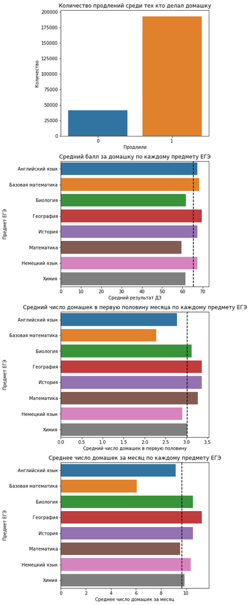

- Графики выше демострируют немного статистики о данных. В основном о ЕГЭ
- Вертикальная сштрихованная линия обозначает среднее
- В списке отстутсвует физика, потому что с данными о ней возникли проблемы при загрузке.
- Удивительно мало решают домашки по Базовой математике.

### Модели

- Традиционно я опущу итерации, когда использовались разные модели, а возьму во внимание лишь те, которые дали сравнительно многообещающие результаты
- Основной проблемой данных является дисбаланс - продлений(среди тех кто хоть как-то решает домашку) гораздо больше чем непродлений
- При помощи специальных методов балансировки данных, мы убрали "предвзятость" модели и добились того, чтобы она не клеймила всех подряд продлившими
- По итогу выполнения модели мы смогли нарисовать "дерево решений", то есть дерево, которое позволяет по входным данным помочь принять решение о том, что тот или иной ученик скорее продлит, или скорее не продлит обучение

### Точности моделей

Мы оценивали модели по 4 видам точности.

- **accuracy** - общая точность, то есть доля правильных предсказаний на фоне неправильных $$acc = \frac{TP+TN}{TP+TN+FP+FN}$$
- **custom_accuracy** - специальная наша точность, без названия, выражающая точночть определения уходящих

$$cus = \frac{TN}{TN+FP}$$

- **precision** - меткость, или вероятность того, что если модель указала, что данный клиент останется, то он действительно останется

$$prec = \frac{TP}{TP+FP}$$

- **false_negative_rate** - вероятность того, что выбранный ученик будет ошибочно признан "уходящим"

$$fnr = \frac{FN}{TN+FN}$$

```
{'acc': 0.6824542672076305,
 'cus': 0.7280880554423156,
 'fnr': 0.6799397871044048,
 'prec': 0.9212403174003401}
```

Выше приведены показатели точности нашей модели

- Низкая общая точность в нашем случае не играет никакой роли
- Для нас важно, чтобы высокими были cus (73%) и prec(92%)
- Все потому что, для нас важно идентефицировать как можно лучше именно уходящих учеников
- Проблема - это большое значение fnr. То есть примерно 68% учеников, которых мы назовём "уходящими" - на самом деле уходить не собирались

[figure not shown]

Выше приведено дерево решений на основе которого можно принимать решения. В териии, такое дерево можно перерисовать и сделать более удобным.

- Значение val олицетворяет долю учеников попавших в ту или иную категорию в процессе обучения модели. Положительные val говорят о том, что это ученики скорее останутся, а отрицательные - уйдут